# 1.6.Publication.Plots

Kevin Bruce

Last compiled on 25 December, 2020

#Load Packages/Data

# JM Figure 3 (Complexity Changes)

- I need to setup a color pallete so that the year color bars from the left sided plots match the corresponding year plots on the right

## Complexity changes (VRM,Rug,Frac)

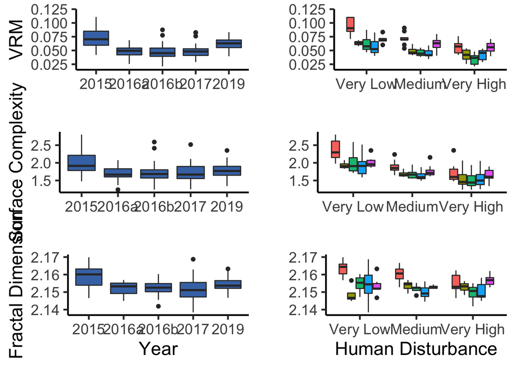

## Curvature Ranges

- I need to check and see if KI2016b_Site30_MPQ1 range value is correct. It is an odd outlier by a large amount, so I feel like it most likely isn’t (probably a math mistake or data collection error)

### Mean vs Range values

```
##  [1] "year"            "pub.site"        "site"            "ppq"
##  [5] "hum_dist"        "hdist.cont"      "sqrt.hdist.cont" "island.side"
##  [9] "region.3"        "region.full"     "DEM"             "year.site.ppq"
## [13] "area_2d"         "area_3d"         "rug"             "vrm"
## [17] "vrm.range"       "curv"            "pro.curv"        "pro.range"
## [21] "plan.curv"       "plan.range"
```

[figure not shown]

### Profile Curvature

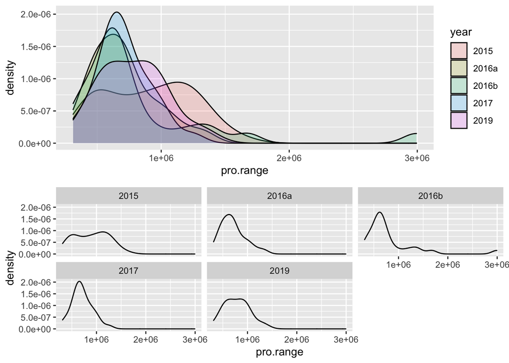

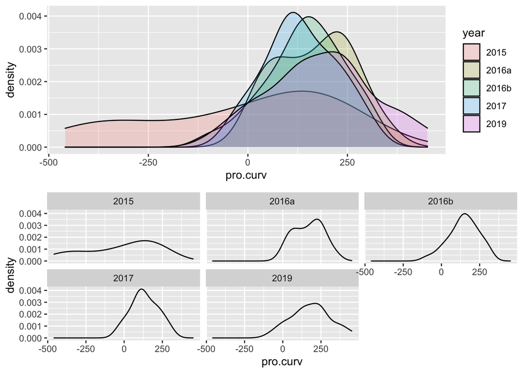